# The apply family of functions

2019-10-02

## Today’s Agenda

- Function optimizing
- Apply functions

## Functions and Timing

As you start to make functions, it is a good idea to think about how long things take.

Really good blog on this here: https://www.r-bloggers.com/5-ways-to-measure-running-time-of-r-code/

Consider the following code and timings:

```r
    library("microbenchmark")
    ## calculate mean of vector
    lvec <- 10000
    vec <- rnorm(lvec)
    times<-microbenchmark(result1<-mean(vec),
                          result2<-sum(vec)/length(vec),
                          result3<-sum(vec)/lvec,times = 100, unit = "ms")
    identical(result1, result2)
```

```
## [1] TRUE
```

## Functions and Timing

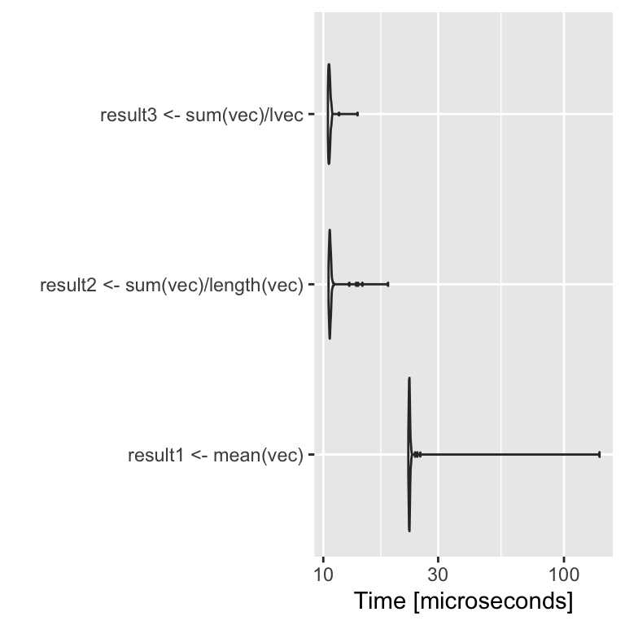

```r
ggplot2::autoplot(times)
```

## Matrix

Last week, we went through matrix operations and hopefully talked about why we don’t invert matrices:

https://www.johndcook.com/blog/2010/01/19/dont-invert-that-matrix/ https://www.r-bloggers.com/dont-invert-that-matrix-why-and-how/

```r
    n <- 2000
    A = matrix(rnorm(n*n, mean=0, sd=5), n, n)
    y <- rnorm(n)
    time1 <- system.time({b_inverting <- solve(A)%*%y})
    time2 <- system.time({b_solving <- solve(A,y)})
    time3 <- system.time({b_matrix_solve <- Matrix::solve(A,y)})

    print(rbind(time1, time2, time3)[,1:3])
```

```
##       user.self sys.self elapsed
## time1     7.222    0.018   7.243
## time2     1.576    0.001   1.578
## time3     2.165    0.029   2.195
```

```r
    max(c(abs(b_inverting - b_solving),abs(b_matrix_solve - b_solving)))
```

```
## [1] 9.264811e-14
```

## For those interested in boosting thier local R

Not all installations of R come accelerated:

*There are several highly optimized libraries that can be used instead of the default base libraries. These libraries are optimized to take advantage of the hardware they are run on, and can be significatantly faster than the base implementation (operations such as Matrix multiplications may be over 40 times faster*  
https://csantill.github.io/RPerformanceWBLAS/

## Apply family of functions

We often want to “apply” a function along a “margin” of our data. In the previous example, we used a matrix operation, but what if we have a custom function we wish to use.

In R, we have helper functions to further simplify our code by obviating the for loop.

Apply family:

apply, lapply , sapply, vapply, mapply, rapply, and tapply

Nice tutorial:  
https://www.r-bloggers.com/r-tutorial-on-the-apply-family-of-functions/

## Apply detail

*apply(X, MARGIN, FUN, …)*

```r
    # ?apply
    x <- cbind(x1 = 3, x2 = c(4:1, 2:5))
    dimnames(x)[[1]] <- letters[1:8]
    x
    apply(x, 2, mean, trim = .2)
    col.sums <- apply(x, 2, sum)
    row.sums <- apply(x, 1, sum)
```

[output not shown]

## What is difference between various apply functions

We could start with the help `?apply, ?sapply`. The main differences are:  
http://www.dummies.com/programming/r/how-to-use-the-apply-family-of-functions-in-r/

## Apply functions

| Function Name | Objects the Function Works On | What the Function Sees as Elements | Result Type |
| --- | --- | --- | --- |
| apply | Matrix | Rows or columns | Vector, matrix, array, or list |
|  | Array | Rows, columns, or any dimension | Vector, matrix, array, or list |
|  | Data frame | Rows or columns | Vector, matrix, array, or list |
| sapply | Vector | Elements | Vector, matrix, or list |
|  | Data frame | Variables | Vector, matrix, or list |
|  | List | Elements | Vector, matrix, or list |
| lapply | Vector | Elements | List |
|  | Data frame | Variables | List |
|  | List | Elements | List |